# Text Mining and Sentiment Analysis

## Corpus: NY Times Articles

Lets look at the NY Times published articles in March 2023. However, I will primarily look at the lead paragraph of each article. The goal is to get an idea of what kind of sentiment is being used within the different sections of each paragraph they offer such as Arts, U.S. and Sports. I will also look into seeing if certain times of the day lends itself more to positive or negative sentiments.

## Connect to NY Times API

```r
api_cnxn <-
  fromJSON(glue("https://api.nytimes.com/svc/archive/v1/2023/3.json?api-key={rstudioapi::askForPassword('Enter NY Times API Key')}"), flatten = TRUE)

ny_times <-
    as.data.frame(api_cnxn) |>
    janitor::clean_names()

write_csv(ny_times, 'ny_times.csv')
```

## Tidy Up Article Data

Clean up column formatting for published dates.

```r
section_df <-
  ny_times |>
  select(response_docs_pub_date, response_docs_section_name, response_docs_lead_paragraph) |>
  mutate(response_docs_pub_date = str_extract(response_docs_pub_date, "[:graph:]*(?=\\+)")) |>
  rename(pub_date = response_docs_pub_date, lead_paragraph = response_docs_lead_paragraph, section = response_docs_section_name)

section_df$pub_date <-
  section_df$pub_date |>
  ymd_hms()

section_df$hour <-
  section_df$pub_date |>
  hour()
```

## Tokenize Sections

```r
tokenize_df <-
  section_df |>
  unnest_tokens(word, lead_paragraph)

knitr::kable(head(tokenize_df))
```

| pub_date | section | hour | word |
| --- | --- | --- | --- |
| 2023-03-01 00:00:07 | Opinion | 0 | to |
| 2023-03-01 00:00:07 | Opinion | 0 | president |
| 2023-03-01 00:00:07 | Opinion | 0 | emmanuel |
| 2023-03-01 00:00:07 | Opinion | 0 | macron |
| 2023-03-01 00:00:07 | Opinion | 0 | of |
| 2023-03-01 00:00:07 | Opinion | 0 | france |

## Categorize Sentiments between Sections

```r
sentiment_df <-
  tokenize_df |>
  inner_join(get_sentiments("bing")) |>
  count(section, sentiment) |>
  pivot_wider(names_from = sentiment, values_from = n, values_fill = 0) |>
  mutate(total_words = negative + positive,
         ovr_sentiment = positive - negative,
        pct = round(ovr_sentiment/total_words *100, 2))

knitr::kable(sentiment_df, caption = "Overall Sentiment based on Section")
```

Overall Sentiment based on Section

| section | negative | positive | total_words | ovr_sentiment | pct |
| --- | --- | --- | --- | --- | --- |
| Admin | 1 | 0 | 1 | -1 | -100.00 |
| Arts | 311 | 484 | 795 | 173 | 21.76 |
| Books | 365 | 354 | 719 | -11 | -1.53 |
| Briefing | 130 | 87 | 217 | -43 | -19.82 |
| Business Day | 458 | 311 | 769 | -147 | -19.12 |
| Climate | 28 | 29 | 57 | 1 | 1.75 |
| Corrections | 51 | 32 | 83 | -19 | -22.89 |
| Crosswords & Games | 104 | 135 | 239 | 31 | 12.97 |
| Education | 11 | 2 | 13 | -9 | -69.23 |
| Fashion & Style | 5 | 5 | 10 | 0 | 0.00 |
| Food | 71 | 173 | 244 | 102 | 41.80 |
| Health | 105 | 39 | 144 | -66 | -45.83 |
| Magazine | 151 | 151 | 302 | 0 | 0.00 |
| Movies | 290 | 328 | 618 | 38 | 6.15 |
| New York | 189 | 166 | 355 | -23 | -6.48 |
| Obituaries | 7 | 8 | 15 | 1 | 6.67 |
| Opinion | 456 | 446 | 902 | -10 | -1.11 |
| Podcasts | 39 | 56 | 95 | 17 | 17.89 |
| Real Estate | 56 | 79 | 135 | 23 | 17.04 |
| Science | 74 | 48 | 122 | -26 | -21.31 |
| Smarter Living | 0 | 2 | 2 | 2 | 100.00 |
| Sports | 161 | 283 | 444 | 122 | 27.48 |
| Style | 114 | 225 | 339 | 111 | 32.74 |
| T Brand | 0 | 1 | 1 | 1 | 100.00 |
| T Magazine | 76 | 124 | 200 | 48 | 24.00 |
| Technology | 40 | 67 | 107 | 27 | 25.23 |
| The Learning Network | 65 | 79 | 144 | 14 | 9.72 |
| The Upshot | 5 | 9 | 14 | 4 | 28.57 |
| Theater | 98 | 121 | 219 | 23 | 10.50 |
| Times Insider | 18 | 17 | 35 | -1 | -2.86 |
| Travel | 38 | 49 | 87 | 11 | 12.64 |
| U.S. | 2672 | 447 | 3119 | -2225 | -71.34 |
| Video | 1 | 0 | 1 | -1 | -100.00 |
| Well | 52 | 39 | 91 | -13 | -14.29 |
| World | 648 | 349 | 997 | -299 | -29.99 |
| Your Money | 4 | 4 | 8 | 0 | 0.00 |

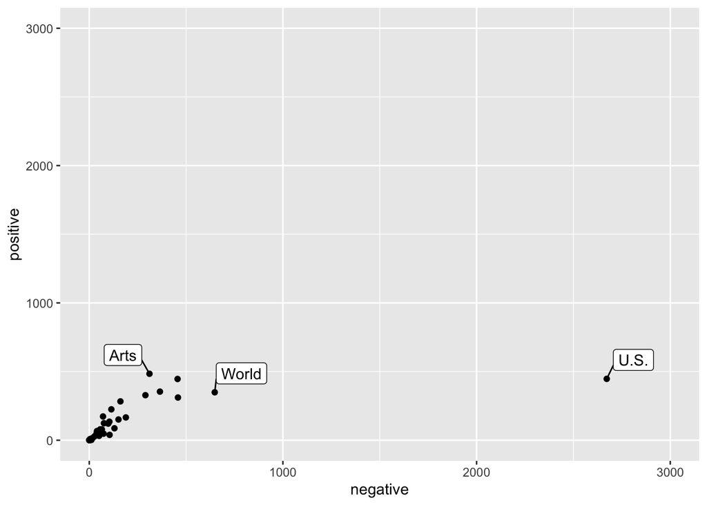

```r
sentiment_df |>
  ggplot(aes(x = negative, y = positive, label = section)) +
  geom_point() +
  geom_label_repel(box.padding = 0.35) +
  xlim(0, 3000) +
  ylim(0, 3000)
```

## Categorize Sentiments between Time of Day

When categorizing based on time of day, 0600 hour has the most positive leading paragraph sentiment at 31%, while at 1200 hour, it has the largest difference in negative sentiment at 88%.

```r
pub_date_df <-
  tokenize_df |>
  inner_join(get_sentiments("bing")) |>
  group_by() |>
  count(hour, sentiment) |>
  pivot_wider(names_from = sentiment, values_from = n, values_fill = 0) |>
  mutate(total_words = negative + positive,
         ovr_sentiment = positive - negative,
        pct = round(ovr_sentiment/total_words *100, 2))

knitr::kable(pub_date_df, caption = "Overall Sentiment based on Hour")
```

Overall Sentiment based on Hour

| hour | negative | positive | total_words | ovr_sentiment | pct |
| --- | --- | --- | --- | --- | --- |
| 0 | 153 | 124 | 277 | -29 | -10.47 |
| 1 | 77 | 53 | 130 | -24 | -18.46 |
| 2 | 77 | 66 | 143 | -11 | -7.69 |
| 3 | 68 | 57 | 125 | -11 | -8.80 |
| 4 | 107 | 115 | 222 | 8 | 3.60 |
| 5 | 84 | 93 | 177 | 9 | 5.08 |
| 6 | 46 | 87 | 133 | 41 | 30.83 |
| 7 | 163 | 164 | 327 | 1 | 0.31 |
| 8 | 80 | 78 | 158 | -2 | -1.27 |
| 9 | 749 | 836 | 1585 | 87 | 5.49 |
| 10 | 554 | 485 | 1039 | -69 | -6.64 |
| 11 | 196 | 170 | 366 | -26 | -7.10 |
| 12 | 2106 | 140 | 2246 | -1966 | -87.53 |
| 13 | 190 | 195 | 385 | 5 | 1.30 |
| 14 | 209 | 208 | 417 | -1 | -0.24 |
| 15 | 326 | 303 | 629 | -23 | -3.66 |
| 16 | 247 | 258 | 505 | 11 | 2.18 |
| 17 | 230 | 225 | 455 | -5 | -1.10 |
| 18 | 173 | 226 | 399 | 53 | 13.28 |
| 19 | 239 | 232 | 471 | -7 | -1.49 |
| 20 | 212 | 177 | 389 | -35 | -9.00 |
| 21 | 221 | 190 | 411 | -31 | -7.54 |
| 22 | 204 | 132 | 336 | -72 | -21.43 |
| 23 | 183 | 135 | 318 | -48 | -15.09 |

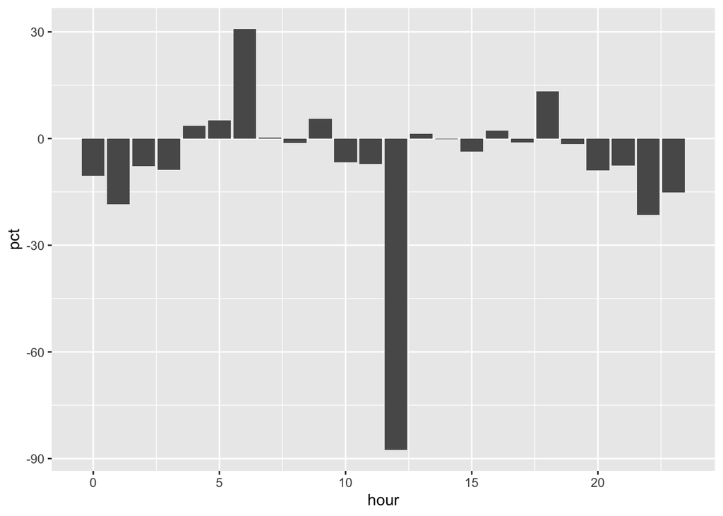

```r
pub_date_df |>
  ggplot(aes(x = hour, y = pct)) +
  geom_bar(stat = 'identity')
```

## Lexicon Library

Researching for other types of lexicon libraries R has to offer, I came across the **lexicon** package. Here it contains many different methods, one of them which is the *hash_sentiment_senticnet()* function. It is a data.table dataset containing an augmented version of Cambria, Poria, Bajpai,& Schuller’s (2016) positive/negative word list as sentiment lookup values. Further documentation can be found [here](https://cran.r-project.org/web/packages/lexicon/lexicon.pdf).

```r
library(lexicon)

knitr::kable(head(hash_sentiment_senticnet), caption = 'Glance of Lookup Values')
```

Glance of Lookup Values

| x | y |
| --- | --- |
| aaa | 0.606 |
| aah | -0.510 |
| abandon | -0.560 |
| abandonment | -0.650 |
| abase | -0.580 |
| abasement | -0.580 |

## Calculate Sentiment based on New Sentiment Lexicon

What we see is that the slope relationship between positive and negative words are much more favorable for positive words when comparing total word counts to each section. This is because I primitively categorized each word based on either being positive or negative without it’s strength value accounted for. However, the U.S. section still shows as the leader for all sections with negative words overall.

```r
lexicon_df <-
  hash_sentiment_senticnet |>
  rename(word = x, value = y)
```

```r
lex_sentiment_df <-
  tokenize_df |>
  inner_join(lexicon_df)

lex_section_df <-
  lex_sentiment_df |>
  mutate(type = case_when(value < 0 ~ "negative",
            value > 0 ~ "positive")) |>
  group_by(section, type) |>
  summarise(total_words = n()) |>
  pivot_wider(names_from = type, values_from = total_words) |>
  mutate(total_words = negative + positive)

knitr::kable(lex_section_df, caption = "Overall Sentiment based on Section")
```

Overall Sentiment based on Section

| section | negative | positive | total_words |
| --- | --- | --- | --- |
| Admin | 2 | 1 | 3 |
| Arts | 1158 | 3207 | 4365 |
| Books | 923 | 2238 | 3161 |
| Briefing | 339 | 925 | 1264 |
| Business Day | 1201 | 3174 | 4375 |
| Climate | 124 | 298 | 422 |
| Corrections | 146 | 435 | 581 |
| Crosswords & Games | 344 | 1031 | 1375 |
| Education | 15 | 35 | 50 |
| Fashion & Style | 23 | 38 | 61 |
| Food | 380 | 1154 | 1534 |
| Headway | 7 | 2 | 9 |
| Health | 258 | 494 | 752 |
| Magazine | 518 | 1088 | 1606 |
| Movies | 931 | 2067 | 2998 |
| New York | 697 | 1796 | 2493 |
| Obituaries | 16 | 35 | 51 |
| Opinion | 1441 | 3372 | 4813 |
| Podcasts | 147 | 414 | 561 |
| Reader Center | 5 | 12 | 17 |
| Real Estate | 320 | 1010 | 1330 |
| Science | 223 | 460 | 683 |
| Smarter Living | 2 | 16 | 18 |
| Special Series | 11 | 8 | 19 |
| Sports | 818 | 1828 | 2646 |
| Style | 596 | 1667 | 2263 |
| T Brand | NA | 4 | NA |
| T Magazine | 355 | 1027 | 1382 |
| Technology | 245 | 702 | 947 |
| The Learning Network | 257 | 852 | 1109 |
| The New York Times Presents | 1 | 4 | 5 |
| The Upshot | 29 | 113 | 142 |
| Theater | 345 | 797 | 1142 |
| Times Insider | 70 | 159 | 229 |
| Travel | 175 | 444 | 619 |
| U.S. | 4121 | 10856 | 14977 |
| Video | 6 | 5 | 11 |
| Well | 175 | 350 | 525 |
| World | 1924 | 4218 | 6142 |
| Your Money | 13 | 30 | 43 |

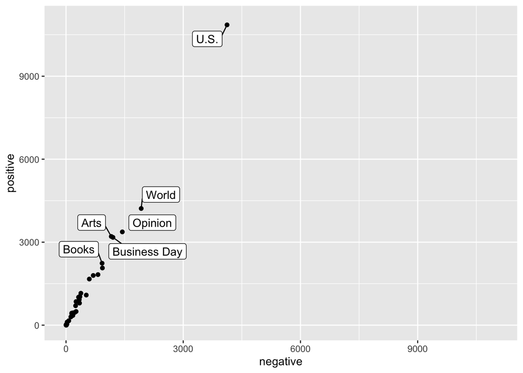

```r
lex_section_df |>
  ggplot(aes(x = negative, y = positive, label = section)) +
  geom_point() +
  geom_label_repel(box.padding = 0.35) +
  xlim(0, 11000) +
  ylim(0, 11000)
```